# Lab 10 binomial regression keys

MATH-7360 Data Analysis

Dr. Xiang Ji @ Tulane University

Oct 23, 2020

```r
rm(list = ls()) # clean-up workspace
library(tidyverse)
library(faraway)
```

# Exercise 3.1 from ELMR.

The question concerns data from a case-control study of esophageal cancer in Ileet-Vilaine, France. The data is distributed with R and may be obtained along with a description of the variables by:

```r
data(esoph)
help(esoph)
```

## (a) Plot the proportion of cases agianst each predictor using the size of the point to indicate the number of subject as seen in figure below.

Comment on the relationships seen in the plots.

```r
lmod <- glm(chd ~ height + cigs, family = binomial, wcgs)
gdf <- wcgs %>%
  mutate(residuals = residuals(lmod), linpred = predict(lmod)) %>%
  group_by(cigs) %>%
  summarise(residuals = mean(residuals), count = n())
```

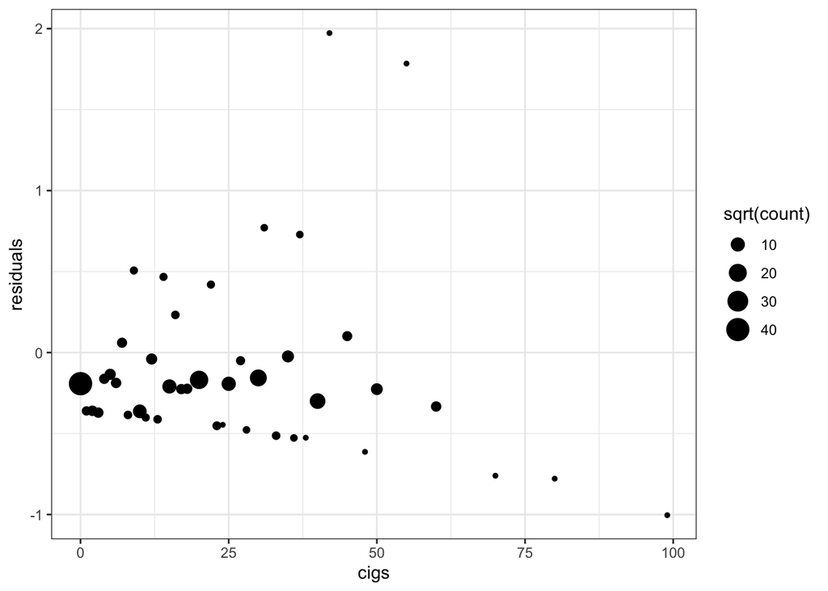

```r
gdf %>%
  ggplot(mapping = aes(x = cigs, y = residuals, size = sqrt(count))) +
  geom_point() +
  theme_bw()
```

**Solutions**:

```r
esoph <- as_tibble(esoph)

# age group
esoph.age <- esoph %>%
  group_by(agegp) %>%
  summarise(count = n(), total_cases = sum(ncases), total_controls = sum(ncontrols),
              percentage=total_cases*100/(total_controls + total_cases))
```

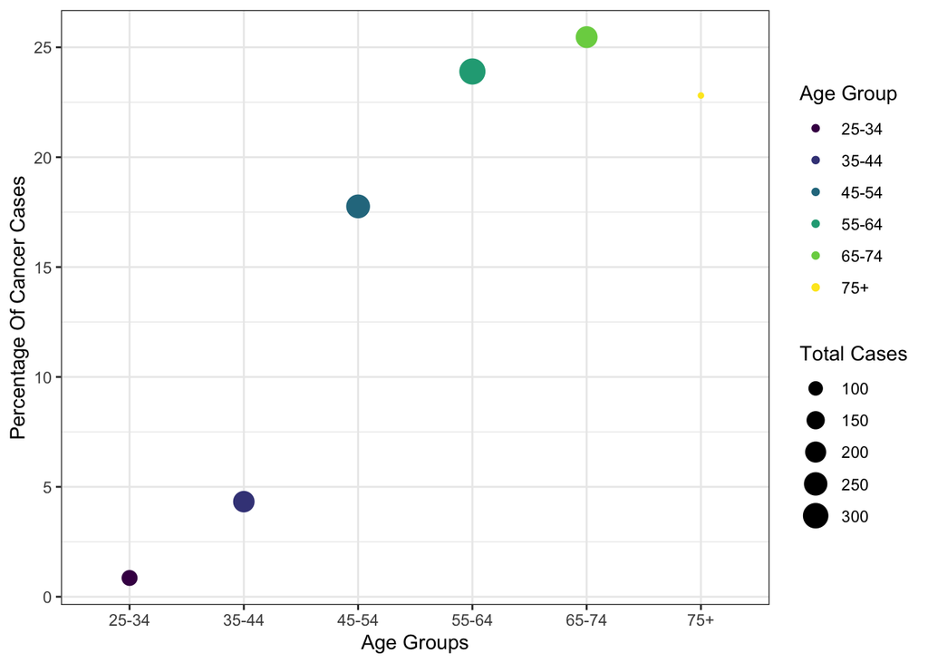

```r
esoph.age %>%
  ggplot(aes(x=agegp, y=percentage, color=agegp, size = total_controls + total_cases)) +
  geom_point() +
  labs(x= 'Age Groups', y= 'Percentage Of Cancer Cases',
       color = "Age Group", size = "Total Cases")+
  theme_bw()
```

```r
# alcohol consumption
esoph.alcgp <- esoph %>%
  group_by(alcgp) %>%
  summarise(count = n(), total_cases = sum(ncases), total_controls = sum(ncontrols),
              percentage=total_cases*100/(total_controls + total_cases))
```

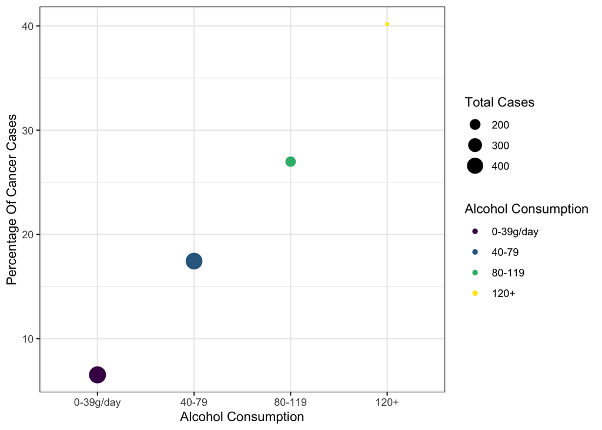

```r
esoph.alcgp %>%
  ggplot(aes(x=alcgp, y=percentage, color=alcgp, size = total_controls + total_cases)) +
  geom_point() +
  labs(x= 'Alcohol Consumption', y= 'Percentage Of Cancer Cases',
       color = "Alcohol Consumption", size = "Total Cases")+
  theme_bw()
```

```r
# tobacco consumption
esoph.tobgp <- esoph %>%
  group_by(tobgp) %>%
  summarise(count = n(), total_cases = sum(ncases), total_controls = sum(ncontrols),
              percentage=total_cases*100/(total_controls + total_cases))
```

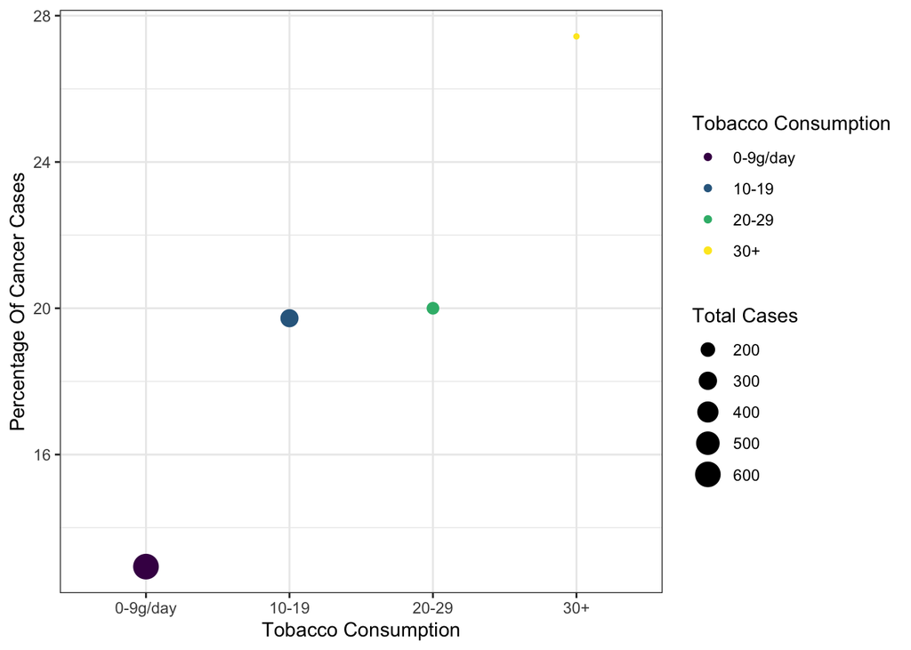

```r
esoph.tobgp %>%
  ggplot(aes(x=tobgp, y=percentage, color=tobgp, size = total_controls + total_cases)) +
  geom_point() +
  labs(x= 'Tobacco Consumption', y= 'Percentage Of Cancer Cases',
       color = "Tobacco Consumption", size = "Total Cases")+
  theme_bw()
```

Percentage of cancer cases seems positively correlated with each of the variables.

## (b) Fit a binomial GLM with interactions between all three preditors.

Use AIC as a criterion to select a model using the `step` function. Which model is selected?

**Solutions**

```r
library(gtsummary)
biglm <- glm(cbind(ncases, ncontrols) ~ (agegp + alcgp + tobgp)^2, family = binomial, data = esoph)
biglm %>%
  tbl_regression(intercept = TRUE)
```

| **Characteristic** | **log(OR)**<sup>1</sup> | **95% CI**<sup>1</sup> | **p-value** |
| --- | --- | --- | --- |
| (Intercept) | -8.7 | -482, 62 | >0.9 |
| agegp.L | 19 | -18, 56 | >0.9 |
| agegp.Q | -17 | -131, 111 | >0.9 |
| agegp.C | 2.8 | -58, 85 | >0.9 |
| agegp^4 | -0.32 | -50, 46 | >0.9 |
| agegp^5 | -1.7 | -14, 9.5 | >0.9 |
| alcgp.L | 3.0 | -5.5, 12 | >0.9 |
| alcgp.Q | 3.0 | -8.6, 15 | >0.9 |
| alcgp.C | 3.1 | -39, 41 | >0.9 |
| tobgp.L | -3.2 | -21, 13 | >0.9 |
| tobgp.Q | -1.6 | -31, 21 | >0.9 |
| tobgp.C | 4.0 | -123, 124 | >0.9 |
| agegp.L * alcgp.L | -7.2 | -57, 30 | >0.9 |
| agegp.Q * alcgp.L | 7.3 | -29, 49 | >0.9 |
| agegp.C * alcgp.L | -6.2 | -40, 20 | >0.9 |
| agegp^4 * alcgp.L | 5.4 | -8.1, 19 | >0.9 |
| agegp^5 * alcgp.L | -2.8 | -8.3, 3.2 | >0.9 |
| agegp.L * alcgp.Q | -9.7 | -113, 106 | >0.9 |
| agegp.Q * alcgp.Q | 4.4 | -118, 129 | >0.9 |
| agegp.C * alcgp.Q | 1.4 | -65, 72 | >0.9 |
| agegp^4 * alcgp.Q | -4.3 | -29, 20 | >0.9 |
| agegp^5 * alcgp.Q | 3.0 | -9.0, 15 | >0.9 |
| agegp.L * alcgp.C | -7.5 | -118, 124 | >0.9 |
| agegp.Q * alcgp.C | 0.39 | -184, 146 | >0.9 |
| agegp.C * alcgp.C | 5.7 | -114, 126 | >0.9 |
| agegp^4 * alcgp.C | -7.0 | -74, 39 | >0.9 |
| agegp^5 * alcgp.C | 3.4 | -13, 21 | >0.9 |
| agegp.L * tobgp.L | 4.6 | -109, 141 | >0.9 |
| agegp.Q * tobgp.L | -4.1 | -46, 38 | >0.9 |
| agegp.C * tobgp.L | -6.7 | -49, 35 | >0.9 |
| agegp^4 * tobgp.L | 5.8 | -63, 90 | >0.9 |
| agegp^5 * tobgp.L | -4.1 | -25, 15 | >0.9 |
| agegp.L * tobgp.Q | 16 | -221, 306 | >0.9 |
| agegp.Q * tobgp.Q | 1.5 | -129, 89 | >0.9 |
| agegp.C * tobgp.Q | 2.1 | -129, 125 | >0.9 |
| agegp^4 * tobgp.Q | 6.2 | -53, 50 | >0.9 |
| agegp^5 * tobgp.Q | -2.0 | -17, 13 | >0.9 |
| agegp.L * tobgp.C | 2.1 | -935, 122 | >0.9 |
| agegp.Q * tobgp.C | 15 | -395, 547 | >0.9 |
| agegp.C * tobgp.C | -1.4 | -106, 68 | >0.9 |
| agegp^4 * tobgp.C | 7.7 | -81, 102 | >0.9 |
| agegp^5 * tobgp.C | -1.0 | -10, 8.0 | >0.9 |
| alcgp.L * tobgp.L | -0.91 | -1.8, 0.00 | 0.046 |
| alcgp.Q * tobgp.L | 0.14 | -0.70, 1.0 | 0.7 |
| alcgp.C * tobgp.L | -0.10 | -0.87, 0.68 | 0.8 |
| alcgp.L * tobgp.Q | 0.28 | -0.60, 1.2 | 0.5 |
| alcgp.Q * tobgp.Q | -0.28 | -1.1, 0.53 | 0.5 |
| alcgp.C * tobgp.Q | 0.16 | -0.59, 0.91 | 0.7 |
| alcgp.L * tobgp.C | -0.31 | -1.2, 0.57 | 0.5 |
| alcgp.Q * tobgp.C | 0.01 | -0.79, 0.81 | >0.9 |
| alcgp.C * tobgp.C | -0.19 | -0.94, 0.54 | 0.6 |

<sup>*1*</sup> OR = Odds Ratio, CI = Confidence Interval

```r
(smalllm <- step(biglm, trace = TRUE))
```

```
## Start:  AIC=265.59
## cbind(ncases, ncontrols) ~ (agegp + alcgp + tobgp)^2
##
##               Df Deviance    AIC
## - agegp:tobgp 15   27.146 246.63
## - agegp:alcgp 15   34.364 253.84
## - alcgp:tobgp  9   23.776 255.26
## <none>             16.109 265.59
##
## Step:  AIC=246.63
## cbind(ncases, ncontrols) ~ agegp + alcgp + tobgp + agegp:alcgp +
##     alcgp:tobgp
##
##               Df Deviance    AIC
## - alcgp:tobgp  9   33.796 235.28
## - agegp:alcgp 15   47.484 236.96
## <none>             27.146 246.63
##
## Step:  AIC=235.28
## cbind(ncases, ncontrols) ~ agegp + alcgp + tobgp + agegp:alcgp
##
##               Df Deviance    AIC
## - agegp:alcgp 15   53.973 225.45
## <none>             33.796 235.28
## - tobgp        3   44.151 239.63
##
## Step:  AIC=225.45
## cbind(ncases, ncontrols) ~ agegp + alcgp + tobgp
##
##         Df Deviance    AIC
## <none>       53.973 225.45
## - tobgp  3   64.572 230.05
## - alcgp  3  120.028 285.51
## - agegp  5  131.484 292.96
```

```
##
## Call:  glm(formula = cbind(ncases, ncontrols) ~ agegp + alcgp + tobgp,
##     family = binomial, data = esoph)
##
## Coefficients:
## (Intercept)      agegp.L      agegp.Q      agegp.C      agegp^4      agegp^5
##    -1.77997      3.00534     -1.33787      0.15307      0.06410     -0.19363
##     alcgp.L      alcgp.Q      alcgp.C      tobgp.L      tobgp.Q      tobgp.C
##     1.49185     -0.22663      0.25463      0.59448      0.06537      0.15679
##
## Degrees of Freedom: 87 Total (i.e. Null);  76 Residual
## Null Deviance:       227.2
## Residual Deviance: 53.97     AIC: 225.5
```

## (c)

All three factors are ordered and so special contrasts have been used approriate for ordered factors involving linear, quadratic and cubic terms. Further simplification of the model may be possible by eliminating some of these terms. Use the `unclass` function to convert the factors to a numerical representation and check whether the model may be simplified.

**Solutions**

```r
esoph.unclassed <- datasets::esoph %>%
  as_tibble() %>%
  mutate(agegp = unclass(agegp),
         alcgp = unclass(alcgp),
         tobgp = unclass(tobgp)) %>%
  print()
```

```
## # A tibble: 88 x 5
##    agegp alcgp tobgp ncases ncontrols
##    <int> <int> <int>  <dbl>     <dbl>
##  1     1     1     1      0        40
##  2     1     1     2      0        10
##  3     1     1     3      0         6
##  4     1     1     4      0         5
##  5     1     2     1      0        27
##  6     1     2     2      0         7
##  7     1     2     3      0         4
##  8     1     2     4      0         7
##  9     1     3     1      0         2
## 10     1     3     2      0         1
## # … with 78 more rows
```

```r
(lastlm <- glm(cbind(ncases, ncontrols) ~ agegp + alcgp + tobgp, family = binomial, data = esoph.unclassed))
```

```
##
## Call:  glm(formula = cbind(ncases, ncontrols) ~ agegp + alcgp + tobgp,
##     family = binomial, data = esoph.unclassed)
##
## Coefficients:
## (Intercept)        agegp        alcgp        tobgp
##     -5.5959       0.5287       0.6938       0.2745
##
## Degrees of Freedom: 87 Total (i.e. Null);  84 Residual
## Null Deviance:       227.2
## Residual Deviance: 73.96     AIC: 229.4
```

```r
lastlm %>%
  tbl_regression(intercept = TRUE)
```

| **Characteristic** | **log(OR)**<sup>1</sup> | **95% CI**<sup>1</sup> | **p-value** |
| --- | --- | --- | --- |
| (Intercept) | -5.6 | -6.4, -4.8 | <0.001 |
| agegp | 0.53 | 0.39, 0.67 | <0.001 |
| alcgp | 0.69 | 0.53, 0.86 | <0.001 |
| tobgp | 0.27 | 0.12, 0.43 | <0.001 |

<sup>*1*</sup> OR = Odds Ratio, CI = Confidence Interval

```r
smalllm.unclassed <- step(lastlm, trace = TRUE)
```

```
## Start:  AIC=229.44
## cbind(ncases, ncontrols) ~ agegp + alcgp + tobgp
##
##         Df Deviance    AIC
## <none>       73.959 229.44
## - tobgp  1   85.310 238.79
## - agegp  1  135.311 288.79
## - alcgp  1  146.355 299.84
```

```r
drop1(smalllm.unclassed, test = "Chisq")
```

```
## Single term deletions
##
## Model:
## cbind(ncases, ncontrols) ~ agegp + alcgp + tobgp
##        Df Deviance    AIC    LRT  Pr(>Chi)
## <none>      73.959 229.44
## agegp   1  135.311 288.79 61.353 4.772e-15 ***
## alcgp   1  146.355 299.84 72.396 < 2.2e-16 ***
## tobgp   1   85.310 238.79 11.351 0.0007539 ***
## ---
## Signif. codes:  0 '***' 0.001 '**' 0.01 '*' 0.05 '.' 0.1 ' ' 1
```

No further variables are dropped by the backward selection.

[Reference](https://ms.mcmaster.ca/~bolker/classes/s756/labs/glmlab.html)

## (d)

Does your final model fit the data? Is the test you make accurate for this data?

**Solutions**

```r
pchisq(smalllm$deviance, smalllm$df.residual, lower = FALSE)
```

```
## [1] 0.9738352
```

```r
drop1(smalllm, test = "Chi")
```

```
## Single term deletions
##
## Model:
## cbind(ncases, ncontrols) ~ agegp + alcgp + tobgp
##        Df Deviance    AIC    LRT  Pr(>Chi)
## <none>      53.973 225.45
## agegp   5  131.484 292.96 77.511 2.782e-15 ***
## alcgp   3  120.028 285.51 66.054 2.984e-14 ***
## tobgp   3   64.572 230.05 10.599   0.01411 *
## ---
## Signif. codes:  0 '***' 0.001 '**' 0.01 '*' 0.05 '.' 0.1 ' ' 1
```

The large p-value indicates that the model has an adequate fit. All three predictors are significant at 0.05 level.

## (e)

Check for outlier in your final model.

**Solutions**

Plot deviance residuals against linear predictors to identify potential high residual observations.

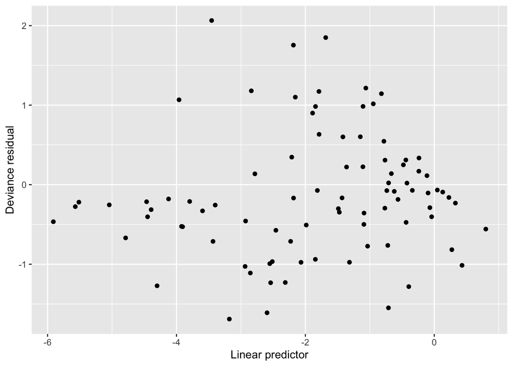

```r
esoph %>%
  mutate(devres = residuals(smalllm, type = "deviance"),
         linpred = predict(smalllm, type = "link")) %>%
  ggplot() +
  geom_point(mapping = aes(x = linpred, y = devres)) +
  labs(x = "Linear predictor", y = "Deviance residual")
```

Plot sorted hat values against half-normal quantiles to identify potential high leverage observations.

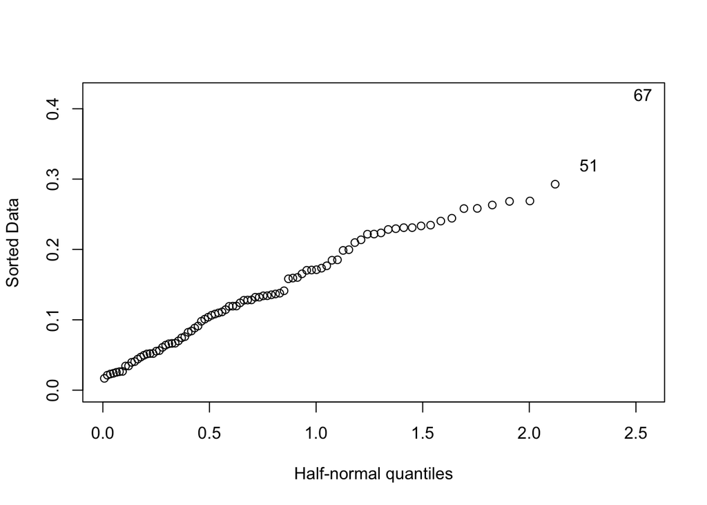

```r
halfnorm(hatvalues(smalllm))
```

```r
esoph %>%
  slice(c(51, 67))
```

```
## # A tibble: 2 x 5
##   agegp alcgp tobgp    ncases ncontrols
##   <ord> <ord> <ord>     <dbl>     <dbl>
## 1 55-64 40-79 0-9g/day      9        40
## 2 65-74 40-79 0-9g/day     17        34
```

Both points have lowest level of tobacco use.

Plot sorted Cook distances against the half-normal quantiles to identify potential high influential observations.

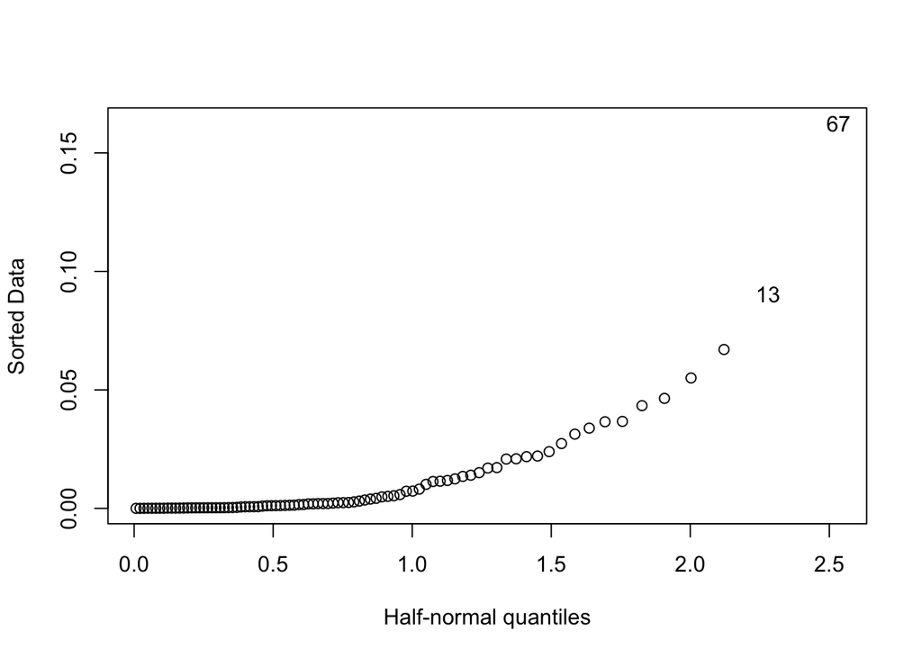

```r
halfnorm(cooks.distance(smalllm))
```

```r
esoph %>%
  slice(c(13, 67))
```

```
## # A tibble: 2 x 5
##   agegp alcgp tobgp    ncases ncontrols
##   <ord> <ord> <ord>     <dbl>     <dbl>
## 1 25-34 120+  10-19         1         1
## 2 65-74 40-79 0-9g/day     17        34
```

One point has lowest level of tobacco use and the other has highest level of alcohol level.

Look at overdispersion

```r
(sigma2 <- sum(residuals(smalllm, type = "pearson")^2) / smalllm$df.residual)
```

```
## [1] 0.7863115
```

No evidence of overdispersion.

Conclusion: we don’t find apparent outliers. The final model has an adequate fit.

## (f)

What is the predicted effect of moving one category higher in alcohol consumption?

**solution**

```r
smalllm %>%
  tbl_regression() %>%
  bold_labels() %>%
  bold_p(t = 0.05)
```

| **Characteristic** | **log(OR)**<sup>1</sup> | **95% CI**<sup>1</sup> | **p-value** |
| --- | --- | --- | --- |
| agegp.L | 3.0 | 2.0, 4.8 | <0.001 |
| agegp.Q | -1.3 | -2.9, -0.39 | 0.024 |
| agegp.C | 0.15 | -0.62, 1.3 | 0.7 |
| agegp^4 | 0.06 | -0.61, 0.66 | 0.8 |
| agegp^5 | -0.19 | -0.58, 0.19 | 0.3 |
| alcgp.L | 1.5 | 1.1, 1.9 | <0.001 |
| alcgp.Q | -0.23 | -0.58, 0.12 | 0.2 |
| alcgp.C | 0.25 | -0.06, 0.57 | 0.11 |
| tobgp.L | 0.59 | 0.21, 1.0 | 0.002 |
| tobgp.Q | 0.07 | -0.30, 0.43 | 0.7 |
| tobgp.C | 0.16 | -0.21, 0.53 | 0.4 |

<sup>*1*</sup> OR = Odds Ratio, CI = Confidence Interval

```r
(beta_hat <- unname(coef(smalllm)))
```

```
##  [1] -1.77996650  3.00533623 -1.33787489  0.15306634  0.06410003 -0.19363171
##  [7]  1.49185165 -0.22663253  0.25463311  0.59448332  0.06536502  0.15679378
```

```r
# on the odds ratio scale
exp(beta_hat[7:9])
```

```
## [1] 4.4453191 0.7972137 1.2899883
```

## (g)

Compute a 95% confidence interval for this predicted effect.

```r
# we focus on the 95% CI on the log odds ratios
smalllm %>%
  tbl_regression() %>%
  bold_labels() %>%
  bold_p(t = 0.05)
```

| **Characteristic** | **log(OR)**<sup>1</sup> | **95% CI**<sup>1</sup> | **p-value** |
| --- | --- | --- | --- |
| agegp.L | 3.0 | 2.0, 4.8 | <0.001 |
| agegp.Q | -1.3 | -2.9, -0.39 | 0.024 |
| agegp.C | 0.15 | -0.62, 1.3 | 0.7 |
| agegp^4 | 0.06 | -0.61, 0.66 | 0.8 |
| agegp^5 | -0.19 | -0.58, 0.19 | 0.3 |
| alcgp.L | 1.5 | 1.1, 1.9 | <0.001 |
| alcgp.Q | -0.23 | -0.58, 0.12 | 0.2 |
| alcgp.C | 0.25 | -0.06, 0.57 | 0.11 |
| tobgp.L | 0.59 | 0.21, 1.0 | 0.002 |
| tobgp.Q | 0.07 | -0.30, 0.43 | 0.7 |
| tobgp.C | 0.16 | -0.21, 0.53 | 0.4 |

<sup>*1*</sup> OR = Odds Ratio, CI = Confidence Interval